# Open Data Source - Final Assignment

Ismo Vihtola ismo.vihtola@hotmail.com

08.03.2017

### Abstract

This is the final assignment for the Open Data Science course that was hold in the beginning of year 2017. Course environment was build by University of Helsinki and the course was done via web platform (MOOC).

In this research I have tried to study if some key figure(s) can be found to predict, which ice-hockey players are better than others when it concern penalty killing. Basic information that was use in this research can be be found on www.hockeyabstract.com,

[This document](https://vihtois.github.io/IODS-final/)  
[Data Wrangling](https://vihtois.github.io/IODS-final/Data_Wrangling.R)

## Research Question

In this research question I try to find if there are some key figures that can predict if the ice-hockey player is when he is playing as a penalty killer. Basic information for this research can be found from http://www.hockeyabstract.com/testimonials.

### Data Wrangling

Information for research questions was collected from http://www.hockeyabstract.com. It is very comprehensive web page concerning NHL stats.  
Description for how dataset(s) that was used in this project can be found from Data Wrangling file that can be found from [here](https://vihtois.github.io/IODS-final/Data_Wrangling.R)

### Explaining the Data

First dataset DB4 will be read into R and its dimensions and structures will be examined

```r
DB3 <- read.table("C:/DATA/Opiskelu/IODS-Final/DB3.csv",sep=",",header=TRUE)
DB4 <- read.table("C:/DATA/Opiskelu/IODS-Final/DB4.csv",sep=",",header=TRUE)
DB4$X <- NULL
dim(DB4)
```

```
## [1] 322   7
```

```r
str(DB4)
```

```
## 'data.frame':    322 obs. of  7 variables:
##  $ GP       : int  82 82 77 81 79 82 66 80 57 82 ...
##  $ Age      : int  29 28 28 27 32 27 21 28 31 36 ...
##  $ SHTOIP60 : int  96 171 81 113 108 106 107 75 119 211 ...
##  $ SHBlkP60 : num  6.86 12.58 6.93 4.33 8.02 ...
##  $ SHTakeP60: num  4.57 0.51 2.89 3.93 5.06 1.66 2.04 1.2 3.18 0.83 ...
##  $ SHPP60   : num  0 0 2.31 0.79 0 1.66 1.02 0 0 0.42 ...
##  $ SHGAP60  : num  3.66 5.39 8.08 5.51 5.49 7.87 7.14 5.4 3.18 7.07 ...
```

The dataset has 322 observations and 7 variables. The variables types are all integer or numeric. Below is table where variables have been clarified.

| Variable | Information |
| --- | --- |
| GP | games played during season |
| Age | players age |
| SHTOIP60 | short-handed time on ice per game per 60 minutes |
| SHBlkP60 | blocks made when playing short-handed per 60 minutes |
| SHTakeP60 | takeaways made when playing short-handed per 60 minutes |
| SHPP60 | points made when playing short-handed per 60 minutes |
| SHGAP60 | goals allowed when playing short-handed per 60 minutes |

Next variables will be looked by graphics. Lets look density plots for them.

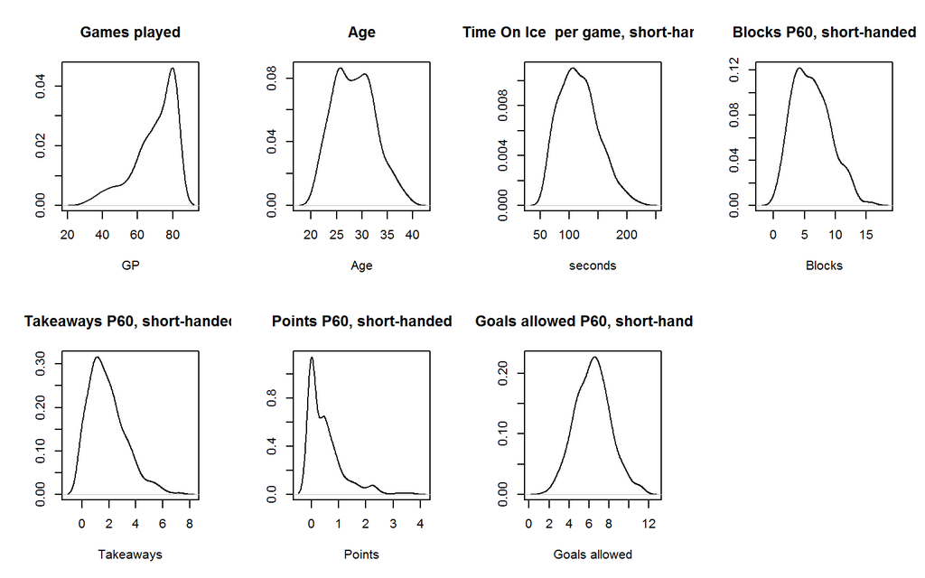

```r
par(mfrow=c(2,4))
plot(density(DB3$GP), main="Games played", xlab="GP", ylab="")
plot(density(DB3$Age), main="Age", xlab="Age", ylab="")
plot(density(DB3$SHTOIP60), main="Time On Ice  per game, short-handed", xlab="seconds", ylab="")
plot(density(DB3$SHBlkP60), main="Blocks P60, short-handed", xlab="Blocks", ylab="")
plot(density(DB3$SHTakeP60), main="Takeaways P60, short-handed", xlab="Takeaways", ylab="")
plot(density(DB3$SHPP60), main="Points P60, short-handed", xlab="Points", ylab="")
plot(density(DB3$SHGAP60), main="Goals allowed P60, short-handed", xlab="Goals allowed", ylab="")
```

Then lets compare relationships between variables with pictures and numbers

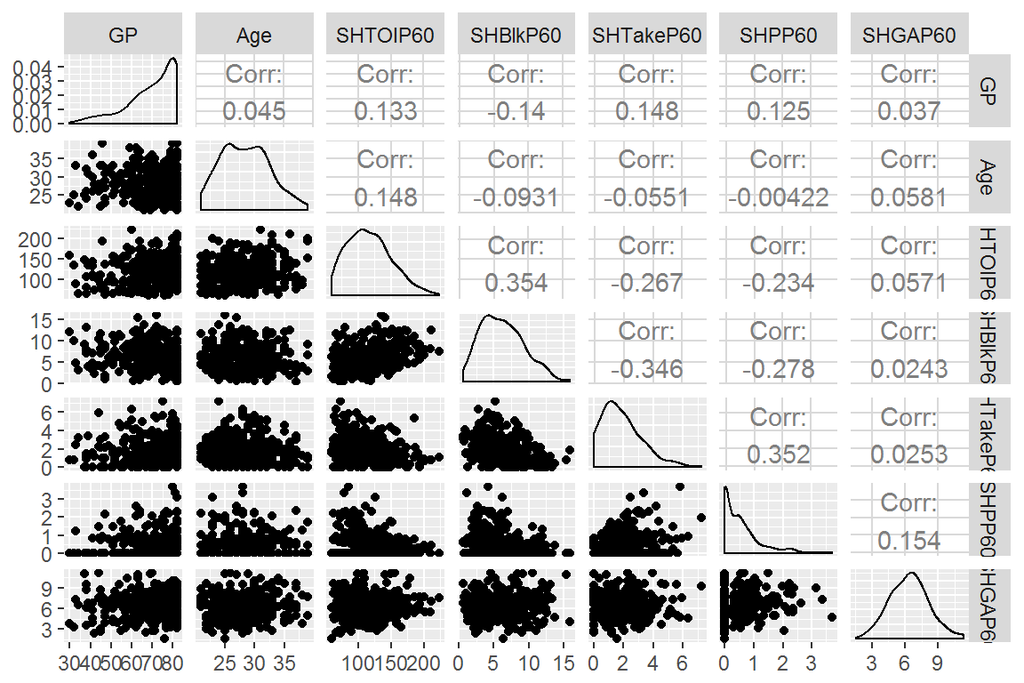

```r
library(GGally)
ggpairs(DB4)
```

This seems intresting, because correlation between variables is quite weak. Strongest correlation is between Blocks and Time On Ice and correlation between them is only 0.354. In general it can be said that there is no strong correlation between variables.

### Linear Discriminant Analysis

To find out research question “Which key figures predicts good penalty kill player?”, Linear Discriminant Analysis (LDA) will be used. LDA is supervised learning method. LDA method seeks to minimize the differences within groups and maximize the differences between groups.

When using LDA, categorial variable is needed. Therefore SHGAP60 variable will be cut to four different sections (low, med_low, med_high, high). SHGP60 variable tell how many goals team have allowed when player has been playing in penalty kliller role. Therefore the lower SHGP60 is, the better results player has achieved.

There are 322 observations and they will be divided to two different groups. First is called train (80% of observations) and other one is called test (20% of observations). Train dataset will be used to create the model and test dataset is going to be use to validate how good model is.

Next the analysis will be made. It is started by scaling dataset.

```r
DB4_scaled <- scale(DB4)
summary(DB4_scaled)
```

```
##        GP               Age             SHTOIP60          SHBlkP60
##  Min.   :-3.2688   Min.   :-1.8520   Min.   :-1.7060   Min.   :-1.85714
##  1st Qu.:-0.4799   1st Qu.:-0.8622   1st Qu.:-0.7484   1st Qu.:-0.79198
##  Median : 0.2583   Median :-0.1199   Median :-0.1050   Median :-0.09151
##  Mean   : 0.0000   Mean   : 0.0000   Mean   : 0.0000   Mean   : 0.00000
##  3rd Qu.: 0.8325   3rd Qu.: 0.6225   3rd Qu.: 0.6207   3rd Qu.: 0.67663
##  Max.   : 0.9965   Max.   : 2.6021   Max.   : 3.1718   Max.   : 3.21205
##    SHTakeP60           SHPP60           SHGAP60
##  Min.   :-1.3640   Min.   :-0.7690   Min.   :-2.73283
##  1st Qu.:-0.7177   1st Qu.:-0.7690   1st Qu.:-0.76501
##  Median :-0.1888   Median :-0.2168   Median : 0.01415
##  Mean   : 0.0000   Mean   : 0.0000   Mean   : 0.00000
##  3rd Qu.: 0.5401   3rd Qu.: 0.3820   3rd Qu.: 0.64828
##  Max.   : 3.9463   Max.   : 5.0013   Max.   : 2.77250
```

When scaling is made, every variables mean is 0 and standard deviation is 1. When scaling has been made it is easier and more meaningful to handle.

Now categorial variable will be created. This is done so that quantiles will be taken from variable SHGAP60 and observations will be classified to classes based on quantiles. Target is to have equal amount of observations to each class. First table below shows quantiles for variable SHGAP60 and the second table below show how observations have been classified to classes. Classification seems to be succesful.

```r
DB4_scaled <- as.data.frame(DB4_scaled)
breakpoints <- quantile(DB4_scaled$SHGAP60)
labels <- c("low", "mod_low", "mod_high", "high")
SHGA_cat <- cut(DB4_scaled$SHGAP60, breakpoints, include.lowest = TRUE, label = labels)
breakpoints
```

```
##          0%         25%         50%         75%        100%
## -2.73282611 -0.76501468  0.01414764  0.64828340  2.77249602
```

```r
table(SHGA_cat)
```

```
## SHGA_cat
##      low  mod_low mod_high     high
##       81       82       78       81
```

Next train and test data will be generated. Train dataset is going to have 80% of all observations and test dataset is going to have 20% of observations.

```r
DB4_scaled <- dplyr::select(DB4_scaled, -SHGAP60)
DB4_scaled <- data.frame(DB4_scaled, SHGA_cat)
n <- nrow(DB4_scaled)
perc8020 <- sample(n, size = n * 0.8)
train <- DB4_scaled[perc8020,]
test <- DB4_scaled[-perc8020,]
dim(train)
```

```
## [1] 257   7
```

```r
dim(test)
```

```
## [1] 65  7
```

So 80% of 322 observation is 257 observation and 20% is 65 observation.  
Finally model will be fitted

```r
library(MASS)
lda.fit <- lda(SHGA_cat ~ ., data = train)
lda.fit
```

```
## Call:
## lda(SHGA_cat ~ ., data = train)
##
## Prior probabilities of groups:
##       low   mod_low  mod_high      high
## 0.2373541 0.2451362 0.2373541 0.2801556
##
## Group means:
##                     GP         Age     SHTOIP60   SHBlkP60    SHTakeP60
## low      -0.1625791959 -0.01441209 -0.194055914  0.1339401 -0.003658256
## mod_low   0.1997119970 -0.05703804  0.253846811  0.2051511  0.085130747
## mod_high -0.1289625688 -0.10365615  0.083609513 -0.1762839 -0.088787216
## high     -0.0003042664  0.12756711 -0.003188187  0.1787032  0.003753569
##               SHPP60
## low      -0.15780354
## mod_low  -0.12486738
## mod_high  0.03674159
## high      0.17567761
##
## Coefficients of linear discriminants:
##                   LD1        LD2         LD3
## GP         0.45147853  0.4289027  0.08661238
## Age        0.39695661 -0.3886268  0.31228958
## SHTOIP60  -0.38129654  0.8051061  0.33019459
## SHBlkP60   1.00264017 -0.1531372  0.07054501
## SHTakeP60  0.42631092  0.3129223 -0.31034272
## SHPP60    -0.08616577 -0.2248823  0.96542559
##
## Proportion of trace:
##    LD1    LD2    LD3
## 0.4448 0.3410 0.2142
```

```r
# Plot
# the function for lda biplot arrows
lda.arrows <- function(x, myscale = 2, arrow_heads = 0.1, color = "black", tex = 1, choices = c(1,2)){
  heads <- coef(x)
  arrows(x0 = 0, y0 = 0,
         x1 = myscale * heads[,choices[1]],
         y1 = myscale * heads[,choices[2]], col=color, length = arrow_heads)
  text(myscale * heads[,choices], labels = row.names(heads),
       cex = tex, col=color, pos=3)
}
```

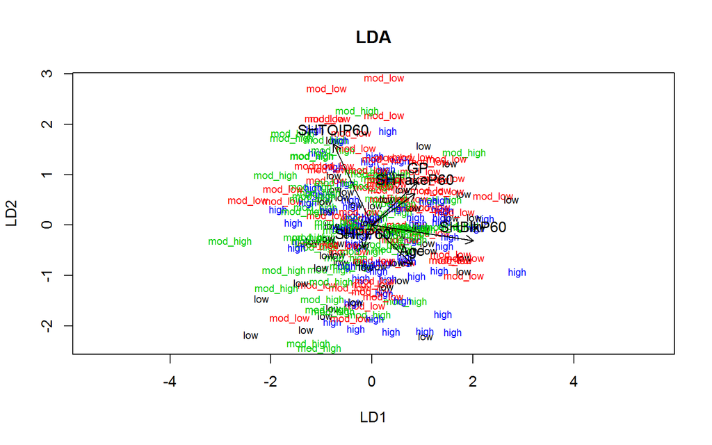

```r
# target classes as numeric
classes <- as.numeric(train$SHGA_cat)
# plot the lda results
plot(lda.fit, dimen = 2, col=classes, pch=classes, main="LDA")
lda.arrows(lda.fit, myscale = 2)
```

Picture is small (fig.width, fig.height does not help) and it makes analysing it quite complicated. But if there would be some key figure that was used in this research it should be separated from others in some way that could be read from picture. In this research classified value **low** should be in it’s own group. Now it seems to be a big mess. At least for me this is a little surprise.

Next we test if model can predict. Expectation is that model won’t predict good.

```r
correct_classes <- test$SHGA_cat
test <- dplyr::select(test, -SHGA_cat)
lda.pred <- predict(lda.fit, newdata = test)
table(correct = correct_classes, predicted = lda.pred$class)
```

```
##           predicted
## correct    low mod_low mod_high high
##   low        2       4        7    7
##   mod_low    4       2        8    5
##   mod_high   1       4        4    8
##   high       1       2        2    4
```

Yep, not even close. There are even observations that was predicted to be high but they were low.

## Conclusions and Discussion

We can conclude that we could not find key figure(s) that could predict if player is good penalty killer or not in this research. Maybe pre chosen variables were not so good as was waited. For me this was suprise, because I was waiting at least some kind of signs.